# Importing, processing, and exploring Xenium data

Data Lab for ALSF

2026

## Objectives

- Read Xenium data into R
- Calculate quality control measures on imaging spatial transcriptomic data
- Remove likely low-quality spots
- Normalize spatial expression data

## Introduction

[Xenium](https://www.10xgenomics.com/platforms/xenium) is 10x Genomics’ *imaging-based* in situ platform. Unlike sequencing-based methods such as single-cell RNA-seq or Visium, Xenium does not sequence anything. Instead, it measures a targeted panel of a few hundred genes directly inside intact tissue by repeated rounds of fluorescence imaging, then computationally decodes those images into individual transcript molecules.

There are two big differences between Xenium and Visium data to be aware of:

- Resolution is subcellular. Each detected transcript has an `(x, y, z)` location in the tissue, and transcripts are assigned to individual cells identified by image segmentation. So the columns of our data are *cells*, not the multi-cell *spots* you get with Visium.
- The gene set is fixed and small. We only measure the genes on the panel (here, 313 genes), so we can’t discover expression of genes that weren’t targeted. As a tradeoff, we get very high sensitivity and spatial precision for the genes we do measure.

In this notebook we will be working with a Xenium human breast cancer dataset. The data come from [Janesick *et al.* (2023)](https://doi.org/10.1038/s41467-023-43458-x), a widely used, publicly available benchmark study that profiled serial formalin-fixed paraffin-embedded (FFPE) human breast cancer sections with matched single-cell RNA-seq, Visium, and Xenium. The Xenium run used the 313-gene human breast panel, which encompasses a 280-gene pre-designed panel plus 33 custom add-on genes.

## Set up

To begin, we’ll load `SpatialExperiment`, the core package for spatial transcriptomic objects in Bioconductor, as well as some packages for plotting.

```r
# The main class we use for spatial transcriptomic data
library(SpatialExperiment)
# To support plotting
library(ggplot2)
library(patchwork)

# Set ggplot2 theme
theme_set(theme_bw())
```

### Directories and files

Xenium data comes as an output bundle produced by the Xenium Onboard Analysis (XOA) pipeline. The specific files present will depend on the Xenium software version and assay, but they are all described in detail in the [10x Genomics documentation](https://www.10xgenomics.com/support/software/xenium-onboard-analysis/latest/analysis/xoa-output-understanding-outputs).

We’ve placed the Xenium output bundle for this breast cancer sample in the directory `data/brca-xenium/xenium`, organized as XOA returns it. Note that we have removed the morphology images since we will not use those here and they take up a lot of space.

We also have an annotations file containing cell type annotations from the original publication. In [Janesick *et al.* (2023)](https://doi.org/10.1038/s41467-023-43458-x), cell types were first annotated using a single-cell RNA-seq dataset from the same tissue. In particular, cells were clustered and clusters were annotated using canonical marker genes. The labels from the single-cell RNA-seq experiment were used as a reference for transferring annotations onto the Xenium cells, giving each segmented cell a cell type call.

We’ll define the path to both the Xenium output directory and the annotations file here.

```r
# main data directory for this sample
data_dir <- file.path("data/brca-xenium")

# directory with xenium output
xenium_outs_dir <- file.path(data_dir, "xenium")

# cell type annotations file
annotations_file <- file.path(data_dir, "Janesick_annotations.tsv")
```

And now, we’ll define the output paths and files we’ll use for exporting.

```r
# Directory and file to save output
normalized_dir <- file.path(data_dir, "normalized")

# create the directory if it does not exist
fs::dir_create(normalized_dir)

# output RDS file for normalized Spatial Experiment (SPE) object
output_spe_file <- file.path(
  normalized_dir,
  "brca_xenium_normalized.rds"
)

# output cell type color palette
output_color_palette_file <- file.path(
  data_dir,
  "brca_xenium_cell_type_palette.tsv"
)
```

## Exploring Xenium outputs

With Visium you run Space Ranger yourself, starting from FASTQ files. Xenium is imaging-based, not sequencing-based, so there are no FASTQs. Instead, the XOA pipeline runs simultaneously on the instrument during data collection. So by the time you get data, the output is already analyzed. The instrument:

- decoded transcripts from the images
- segmented cells
- assigned transcripts to cells
- and built the count matrix

Let’s look at what’s in the bundle:

```r
dir(xenium_outs_dir)
```

```
 [1] "analysis"                     "analysis_summary.html"
 [3] "analysis.zarr.zip"            "cell_boundaries.csv.gz"
 [5] "cell_boundaries.parquet"      "cell_feature_matrix"
 [7] "cell_feature_matrix.h5"       "cell_feature_matrix.zarr.zip"
 [9] "cells.csv.gz"                 "cells.parquet"
[11] "cells.zarr.zip"               "experiment.xenium"
[13] "gene_panel.json"              "metrics_summary.csv"
[15] "nucleus_boundaries.csv.gz"    "nucleus_boundaries.parquet"
[17] "transcripts.csv.gz"           "transcripts.parquet"
[19] "transcripts.zarr.zip"
```

[output not shown]

Below are brief descriptions of the core files in a Xenium output bundle. Not every file is always present since it depends on the software version and the exact assay used. The [10x Genomics documentation](https://www.10xgenomics.com/support/software/xenium-onboard-analysis/latest/analysis/xoa-output-understanding-outputs) is the authoritative reference for the full list.

##### `experiment.xenium`

A JSON file of run-level metadata including the gene panel, pixel size, software versions, and file paths. This is the entry-point file that most loaders read first.

##### `cell_feature_matrix.h5` (and `cell_feature_matrix/`, `cell_feature_matrix.zarr.zip`)

The cell-by-feature count matrix, analogous to the feature-barcode matrix from Cell Ranger/Space Ranger. Rows are features (panel genes plus control categories) and columns are segmented cells. It contains only transcripts that passed the default quality threshold (Q-Score ≥ 20). The same data are provided in HDF5 (`.h5`), a Matrix Market directory, and Zarr formats; we will we use the `.h5` version.

##### `cells.parquet` / `cells.csv.gz` (and `cells.zarr.zip`)

This file provides our spatial coordinates and column (cell) metadata. It includes each cell’s ID, centroid coordinates (`x_centroid`, `y_centroid`) in microns, cell and nucleus area, transcript counts, and the segmentation method used.

##### `transcripts.parquet` / `transcripts.csv.gz`

This file contains the individual decoded transcript molecules, each with an `(x, y, z)` location, the gene it decoded to, a quality score, and the cell it was assigned to (if any). This subcellular, molecule-level table is what distinguishes Xenium from spot-based methods. It is somewhat similar to `tissue_positions_list.csv` in Visium, but at far higher resolution.

##### `cell_boundaries.parquet` and `nucleus_boundaries.parquet` (plus `.csv.gz` versions)

These files describe the polygons that define each cell’s and each nucleus’s segmentation outline. These polygons are useful for plotting and for calculating QC metrics like cell area and shape. Nucleus boundaries come from segmenting the DAPI image and cell boundaries come from expanding or otherwise extending those nuclei (see the segmentation note below). The count matrix is summarized at the **cell** level so that transcripts are assigned to the cell polygons. This means that `cell_boundaries` correspond to the columns of our object (or `spots` in Visium), while `nucleus_boundaries` is supplementary information about the nuclear compartment.

##### `analysis/` and `analysis.zarr.zip`

These files contain automated secondary analysis (e.g., dimensionality reduction and clustering) that are produced on-instrument.

##### `metrics_summary.csv` and `analysis_summary.html`

Run-level QC summaries as a CSV and a HTML report which includes transcript quality, segmentation method breakdown, control rates, and similar diagnostics.

##### Morphology images (`morphology.ome.tif`, `morphology_mip.ome.tif`, `morphology_focus.ome.tif` / `morphology_focus/`)

The tissue morphology images, including the DAPI nuclear stain and any additional stains that might be present for multi-modal assays. We don’t include these here to save space, but they are what you would use to visually inspect or re-run segmentation.

### Import with `SpatialExperimentIO`

We’ll import the counts and spatial information into a `SpatialExperiment` (SPE) object using the `SpatialExperimentIO` package. Note that here we are not using `VisiumIO` as our dataset is from Xenium, which is distinct from the previous Visium data sets we have been working with.

The only argument the function strictly requires is the path to the output bundle directory. In the code below, we set a few arguments explicitly, like the count matrix and per-cell metadata, just so we can see what files are required, but we are still using the defaults.

By default, the function also moves the Xenium control features (negative control probes, negative control codewords, unassigned codewords, etc.) out of the main gene matrix and into `altExps`, and adds the `experiment.xenium` metadata and the transcript/boundary parquet paths to `metadata()`.

```r
spe <- SpatialExperimentIO::readXeniumSXE(
  xenium_outs_dir, # path to the Xenium bundle (required)
  countMatPattern = "cell_feature_matrix.h5", # default
  metaDataPattern = "cells.parquet", # default
  coordNames = c("x_centroid", "y_centroid") # default; columns used as spatialCoords
)
```

Let’s have a look:

```r
# print the spe
spe
```

```
class: SpatialExperiment
dim: 313 167780
metadata(4): experiment.xenium transcripts cell_boundaries
  nucleus_boundaries
assays(1): counts
rownames(313): ABCC11 ACTA2 ... ZEB2 ZNF562
rowData names(3): ID Symbol Type
colnames(167780): 1 2 ... 167779 167780
colData names(8): cell_id transcript_counts ... nucleus_area sample_id
reducedDimNames(0):
mainExpName: NULL
altExpNames(4): NegControlProbe NegControlCodeword antisense BLANK
spatialCoords names(2) : x_centroid y_centroid
imgData names(0):
```

A few things to notice about this object:

- The dimensions show only 313 genes and roughly 167,000 cells. The gene count is small because Xenium measures a targeted panel, and because the control features have been split off into `altExps` (so the main matrix is genes only).
- Each column corresponds to one cell. There are no barcodes, or spot barcodes, just cell ids.
- The `spatialCoords` hold the `x_centroid`/`y_centroid` values in microns, while gene-level counts live in the `counts` assay.

Let’s go ahead and plot the coordinates here. Unlike with Visium, Xenium does not natively have an H&E image. An H&E image can be added to the object downstream, but we won’t be working with one with this dataset.

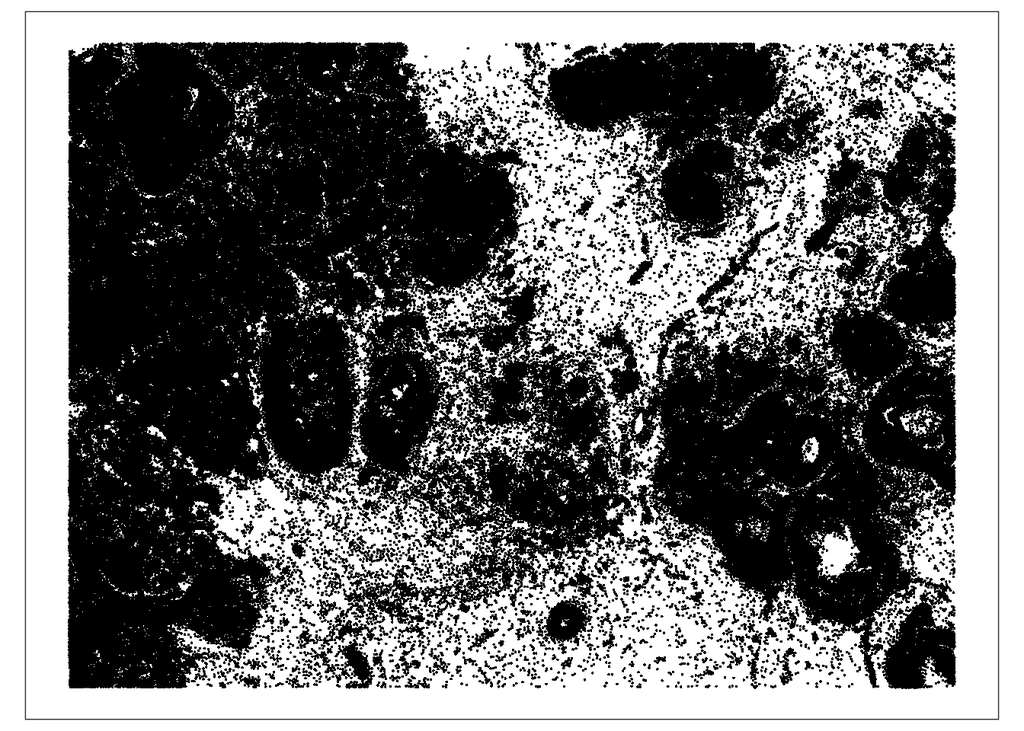

```r
# needed to be able to plot the coordinates with ggspavis
spe$in_tissue <- TRUE

# plot just the spots
ggspavis::plotCoords(spe)
```

### A note on segmentation

Because Xenium reports data per cell, every count depends on the cell segmentation step. Segmentation employs a computational algorithm to identify a boundary for each cell and decides which transcripts belong to each cell. Segmentation quality therefore directly affects downstream results, but no current method handles every tissue perfectly. Different cell types, such as neurons and muscle cells have non-cuboidal shapes so segmentation approaches for tissues with those cell types maybe more difficult than others. Improving segmentation remains an active area of research.

The Xenium Onboard Analysis pipeline segments cells in two broad ways depending on the assay ([10x Genomics segmentation algorithms](https://www.10xgenomics.com/support/software/xenium-onboard-analysis/latest/algorithms-overview/segmentation)):

- **Nuclear expansion:** Nuclei are detected from the DAPI stain, then each nucleus boundary is expanded outward (isotropically, up to ~5 µm by default) to approximate the cell body.
- **Multimodal cell segmentation:** When the multi-tissue stain mix is used, a cell boundary stain (identified through membrane markers such as ATP1A1/CD45/E-Cadherin) is used to identify the true cell membrane, and an interior stain (18S rRNA) is used alongside the DAPI stain to identify the nuclei. In this scenario, nuclear expansion is used as a fallback.

This particular dataset only included a DAPI stain so cell segmentation was done using nuclear expansion.

### A note on control features and `altExps`

A Xenium panel includes probes for both targeted genes and control probes.

To understand the control categories, it helps to know how Xenium turns images into counts. Each targeted gene is detected not by sequencing but by a characteristic pattern of fluorescent signals at a specific site (punctum) across imaging channels and cycles. That pattern is called a **codeword**, and the full lookup table mapping codewords to genes is the **codebook** ([10x Genomics Xenium panel design concepts and terms](https://www.10xgenomics.com/support/software/xenium-panel-designer/latest/tutorials/xenium-panel-design-concepts-terms)). Decoding is the process of reading the observed signal at each detected fluorescent punctum and matching it to a codeword (and therefore a gene), with a quality score attached to each call.

The codebook deliberately reserves some codewords and probes as controls, which let us estimate background and error rates:

- **Negative control probes** are physical probes included in the panel that target sequences *not* present in the transcriptome. Counts on these reflect nonspecific probe binding, so they measure assay background.
- **Negative control codewords** are valid codewords that are deliberately left unassigned to any real probe in the panel. Counts on these reflect optical or decoding errors, so they measure decoding specificity.
- **Antisense** are probes targeting the antisense strand. Counts on these reflect nonspecific probe binding and measure assay background.
- **BLANK** codewords are unused codewords. There is no probe in a particular gene panel that will generate the codeword. These are also used to identify decoding specificity. Note that although the probes are named with `BLANK` these correspond to Unassigned codewords described in the [10x documentation](https://www.10xgenomics.com/support/software/xenium-onboard-analysis/latest/algorithms-overview/xoa-algorithms#qvs).

Because a high-quality cell should have essentially no control counts, these features are a powerful QC signal and we will use them below. To keep control counts from being mistaken for real gene counts, `readXeniumSXE()` moves them out of the main matrix and into alternative experiments (`altExps`) stored alongside the main object. These can be accessed with `altExp()`.

We can see which control experiments were separated out here:

```r
# control features are stored separately from the gene panel, as altExps
altExpNames(spe) |>
  purrr::set_names() |>
  purrr::map(\(name) altExp(spe, name))
```

```
$NegControlProbe
class: SpatialExperiment
dim: 20 167780
metadata(0):
assays(1): counts
rownames(20): NegControlProbe_00042 NegControlProbe_00041 ...
  NegControlProbe_00003 NegControlProbe_00002
rowData names(3): ID Symbol Type
colnames(167780): 1 2 ... 167779 167780
colData names(8): cell_id transcript_counts ... nucleus_area sample_id
reducedDimNames(0):
mainExpName: NULL
altExpNames(0):
spatialCoords names(2) : x_centroid y_centroid
imgData names(0):

$NegControlCodeword
class: SpatialExperiment
dim: 41 167780
metadata(0):
assays(1): counts
rownames(41): NegControlCodeword_0500 NegControlCodeword_0501 ...
  NegControlCodeword_0539 NegControlCodeword_0540
rowData names(3): ID Symbol Type
colnames(167780): 1 2 ... 167779 167780
colData names(8): cell_id transcript_counts ... nucleus_area sample_id
reducedDimNames(0):
mainExpName: NULL
altExpNames(0):
spatialCoords names(2) : x_centroid y_centroid
imgData names(0):

$antisense
class: SpatialExperiment
dim: 8 167780
metadata(0):
assays(1): counts
rownames(8): antisense_PROKR2 antisense_ULK3 ... antisense_BCL2L15
  antisense_ADCY4
rowData names(3): ID Symbol Type
colnames(167780): 1 2 ... 167779 167780
colData names(8): cell_id transcript_counts ... nucleus_area sample_id
reducedDimNames(0):
mainExpName: NULL
altExpNames(0):
spatialCoords names(2) : x_centroid y_centroid
imgData names(0):

$BLANK
class: SpatialExperiment
dim: 159 167780
metadata(0):
assays(1): counts
rownames(159): BLANK_0006 BLANK_0013 ... BLANK_0497 BLANK_0499
rowData names(3): ID Symbol Type
colnames(167780): 1 2 ... 167779 167780
colData names(8): cell_id transcript_counts ... nucleus_area sample_id
reducedDimNames(0):
mainExpName: NULL
altExpNames(0):
spatialCoords names(2) : x_centroid y_centroid
imgData names(0):
```

## Add in cell type annotations

For this dataset, we have published cell type annotations, which we can join onto our object’s cell metadata.

```r
# read the cell type annotations
cell_types_df <- readr::read_tsv(annotations_file)
head(cell_types_df)
```

| cell_id | cell_type_annotation |
| --- | --- |
| 1 | DCIS_2 |
| 2 | DCIS_2 |
| 3 | Unlabeled |
| 4 | Invasive_Tumor |
| 5 | DCIS_2 |
| 6 | Unlabeled |

```r
# how many cells of each annotated type?
cell_types_df |>
  dplyr::count(cell_type_annotation) |>
  dplyr::arrange(desc(n))
```

| cell_type_annotation | n |
| --- | --- |
| Stromal | 41422 |
| Invasive_Tumor | 34374 |
| DCIS_1 | 12923 |
| DCIS_2 | 11683 |
| Macrophages_1 | 11174 |
| Endothelial | 8931 |
| Unlabeled | 8554 |
| CD4+_T_Cells | 8453 |
| Myoepi_ACTA2+ | 7078 |
| CD8+_T_Cells | 6940 |

[output cut: 10 more lines]

The original annotations are fairly fine-grained. To make plots easier to read, we’ll collapse related labels into broader groups in a new `cell_types_lumped` column.

```r
cell_types_df <- cell_types_df |>
  dplyr::mutate(
    cell_types_lumped = dplyr::case_when(
      stringr::str_detect(cell_type_annotation, "Macrophages") ~ "Macrophage",
      stringr::str_detect(cell_type_annotation, "DCIS") ~ "DCIS",
      stringr::str_detect(
        cell_type_annotation,
        "Myoepi"
      ) ~ "Myoepithelial cell",
      stringr::str_detect(cell_type_annotation, "Hybrid") ~ "Hybrid",
      stringr::str_detect(cell_type_annotation, "Tumor") ~ "Tumor",
      stringr::str_detect(cell_type_annotation, "DCs") ~ "Dendritic cell",
      .default = cell_type_annotation
    ) |>
      stringr::str_replace_all("_", " ")
  )

# check the counts of the lumped categories
cell_types_df |>
  dplyr::count(cell_types_lumped) |>
  dplyr::arrange(desc(n))
```

| cell_types_lumped | n |
| --- | --- |
| Stromal | 41422 |
| Tumor | 38149 |
| DCIS | 24606 |
| Macrophage | 12798 |
| Myoepithelial cell | 9938 |
| Endothelial | 8931 |
| Unlabeled | 8554 |
| CD4+ T Cells | 8453 |
| CD8+ T Cells | 6940 |
| B Cells | 4987 |

[output cut: 4 more lines]

Now we join the annotations onto the object’s `colData` by `cell_id`. Cells that are not present in the annotation file will be assigned as `NA`.

```r
# join cell types with coldata
coldata_df <- colData(spe) |>
  as.data.frame() |>
  dplyr::left_join(cell_types_df, by = "cell_id")

# replace existing coldata with updated coldata
colData(spe) <- DataFrame(coldata_df)

head(colData(spe))
```

```
DataFrame with 6 rows and 11 columns
    cell_id transcript_counts control_probe_counts control_codeword_counts
  <numeric>         <integer>            <integer>               <integer>
1         1                28                    1                       0
2         2                94                    0                       0
3         3                 9                    0                       0
4         4                11                    0                       0
5         5                48                    0                       0
6         6                 7                    0                       0
  total_counts cell_area nucleus_area   sample_id in_tissue
     <integer> <numeric>    <numeric> <character> <logical>
1           29   58.3870      26.6422    sample01      TRUE
2           94  197.0167      42.1308    sample01      TRUE
3            9   16.2563      12.6889    sample01      TRUE
4           11   42.3114      10.0698    sample01      TRUE
5           48  107.6525      37.4797    sample01      TRUE
6            7   27.6356      10.3859    sample01      TRUE
  cell_type_annotation cell_types_lumped
           <character>       <character>
1               DCIS_2              DCIS
2               DCIS_2              DCIS
3            Unlabeled         Unlabeled
4       Invasive_Tumor             Tumor
5               DCIS_2              DCIS
6            Unlabeled         Unlabeled
```

To keep colors consistent across plots, we’ll build a single named palette mapping each lumped cell type to a color, and reuse it.

```r
# build a custom palette
cell_type_palette <- c(
  "Stromal" = "#F6222E",
  "Tumor" = "#3283FE",
  "DCIS" = "#325A9B",
  "Macrophage" = "#85660D",
  "Myoepithelial cell" = "#F7E1A0",
  "Endothelial" = "#AA0DFE",
  "CD4+ T Cells" = "#16FF32",
  "CD8+ T Cells" = "#1C8356",
  "B Cells" = "#FC1CBF",
  "Perivascular-Like" = "#FEAF16",
  "Dendritic cell" = "#1CBE4F",
  "Mast Cells" = "#565656",
  "Hybrid" = "#FFFF00",
  "Unlabeled" = "grey90"
)
```

Finally, we’ll use factors to define the order of the cell types so that they appear in the legend in the same order that we have defined above rather than in alphabetical order.

```r
# re-order celltypes for plotting by setting them as a factor
# and matching the order in the palette
spe$cell_types_lumped <- as.factor(spe$cell_types_lumped) |>
  forcats::fct_relevel(names(cell_type_palette))
```

Now that we have prepared our data, we can create our plot showing the lumped cell type annotations across the slide using `ggspavis::plotCoords()`.

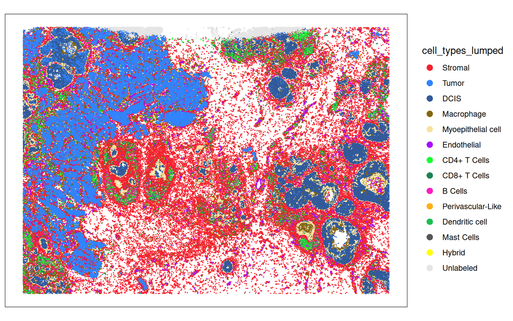

```r
# plot all spots colored by cell type
ggspavis::plotCoords(spe, annotate = "cell_types_lumped") +
  scale_color_manual(values = cell_type_palette)
```

## Identifying low quality cells

Cells from imaging based methods can be considered low-quality for one of two reasons:

1. The cell has a high level of background noise or has had issues decoding the codewords, as indicated by high per-cell counts for the negative control probes or negative codewords. For Xenium, this information is stored in `control_probe_counts` and `control_codeword_counts` in the `colData`.
2. The cell has a low number of gene expression counts compared to other cells of the same size, indicating the cells may be debris or segmentation artifacts. For Xenium, this information is stored in `total_counts` and `cell_area` in the `colData`.

**Note:** For other imaging based methods, this information may not be pre-calculated. In this case the [`SpaceTrooper` package](https://bioconductor.org/packages/SpaceTrooper) ([Banzi *et al.,* 2025](https://doi.org/10.64898/2025.12.24.696336)) can be used to compute per-cell quality-control metrics that are tailored to imaging-based spatial data. Additionally, the exact filtering steps shown here may not be applicable for all imaging based platforms. Please consult [OSTA section on quality control for imaging-based platforms](https://bioconductor.org/books/release/OSTA/pages/img-quality-control.html) for more details.

Low-quality cells tend to be outliers in the relationship between total counts and cell area. Cells with very few counts for their area are often debris or segmentation artifacts. Below we can color the cells by these QC metrics.

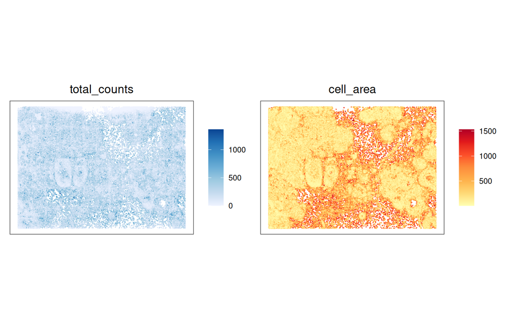

```r
p1 <- ggspavis::plotCoords(spe, annotate = "total_counts") +
  ggplot2::scale_color_distiller(palette = "Blues", direction = 1)

p2 <- ggspavis::plotCoords(spe, annotate = "cell_area") +
  ggplot2::scale_color_distiller(palette = "YlOrRd", direction = 1)

p1 + p2
```

To flag these cells, we summarize each cell by its counts-per-area ratio and look for cells that sit far below the bulk of the distribution. Specifically, we use `scuttle::isOutlier()` to flag cells whose ratio falls more than three median absolute deviations (MADs) below the median.

- The MAD is a robust measure of spread and is less sensitive to extreme values than the standard deviation.
- We will use the common cutoff of 3 * MAD.
- We only flag the low side, since it is unusually *few* counts for a cell’s area that signals debris or a failed segmentation.
- We work on the log scale because the ratio is strictly positive and right-skewed. Using the log scale will make the distribution more symmetric which is what is assumed when using the 3 * MAD rule.

```r
# counts-per-area ratio for each cell
count_area_ratio <- spe$total_counts / spe$cell_area

# flag cells that are outliers on the low side
# (3 median absolute deviations below the median, on the log2 scale since the metric is a ratio)
outliers <- scuttle::isOutlier(
  count_area_ratio,
  log = TRUE,
  type = "lower",
  nmads = 3
)

# print the structure which tells us where to find the identified threshold
str(outliers)
```

```
 'outlier.filter' logi [1:167780] FALSE FALSE FALSE FALSE FALSE FALSE ...
 - attr(*, "thresholds")= Named num [1:2] 0.171 Inf
  ..- attr(*, "names")= chr [1:2] "lower" "higher"
```

Now we can pull out the specific threshold corresponding to 3 MADs below the median from the `outliers` object.

```r
# pull out the numeric threshold for plotting
threshold <- attr(outliers, "threshold")[1]
```

We’ll also plot the distribution of the ratio and the chosen cutoff.

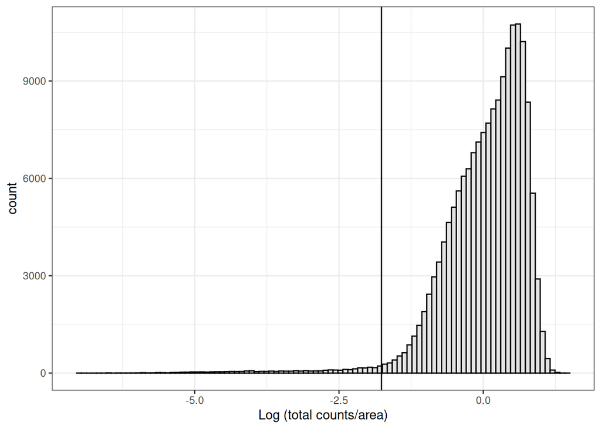

```r
# visualize the distribution and the chosen threshold
ggplot(mapping = aes(log(count_area_ratio))) +
  geom_histogram(bins = 100, fill = "grey90", color = "black") +
  theme_bw() +
  geom_vline(xintercept = log(threshold)) +
  labs(
    x = "Log (total counts/area)"
  )
```

## Filtering low quality spots

Now we can filter by combining the counts-per-area QC metric with information from the control features as a secondary quality signal. A high-quality cell should have essentially no control counts. Any counts in these categories indicate background or errors in that cell. Therefore we exclude cells with a nonzero count in either control category or with a counts-per-area ratio below the cutoff.

First, let’s look at what cells get filtered by using just the counts-per-area QC metric.

```r
# how many cells would get filtered?
sum(outliers)
```

```
[1] 4580
```

Where in the sample do the outliers appear?

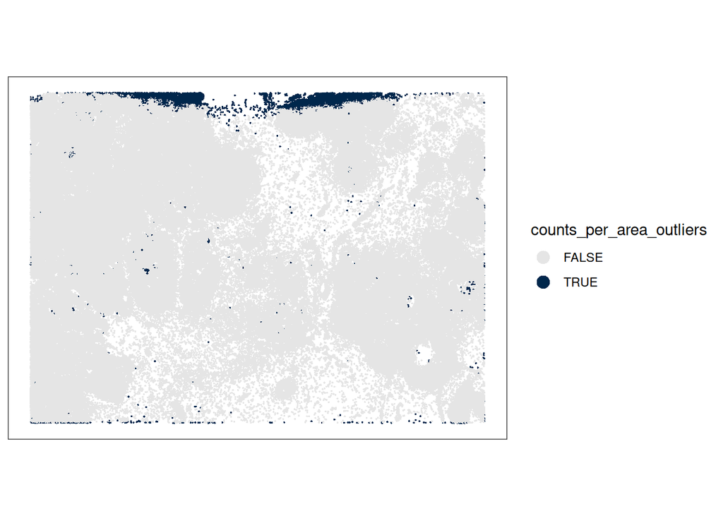

```r
# now visualize them using the spatial coordinates
spe$counts_per_area_outliers <- outliers

ggspavis::plotCoords(spe, annotate = "counts_per_area_outliers") +
  guides(color = guide_legend(override.aes = list(size = 4))) +
  # add custom colors so excluded cells are easy to see
  scale_color_manual(values = c("grey90", "#00274C"))
```

It looks like most of the cells that would be excluded if we used this metric alone are towards the edges of the tissue. This is likely an artifact of the tissue placement.

Now, let’s look at cells that get filtered by using just the control metrics. These are cells with either `control_probe_counts` or `control_codeword_counts` > 0.

```r
# add a column indicating if the cell has any control probes detected
spe$control_exclude <- spe$control_probe_counts > 0 |
  spe$control_codeword_counts > 0

# how many cells would be excluded
sum(spe$control_exclude)
```

```
[1] 23007
```

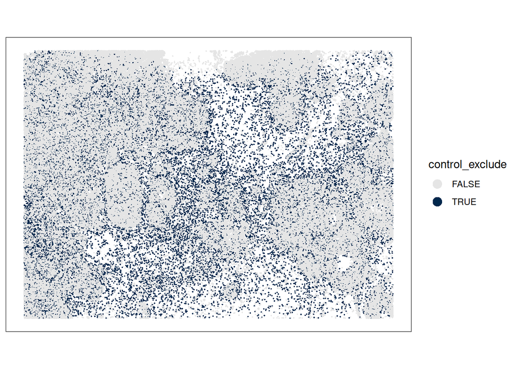

```r
ggspavis::plotCoords(spe, annotate = "control_exclude") +
  guides(color = guide_legend(override.aes = list(size = 4))) +
  # add custom colors so excluded cells are easy to see
  scale_color_manual(values = c("grey90", "#00274C"))
```

In contrast, the cells that have controls detected and are therefore considered low-quality tend to be scattered randomly throughout the tissue, which is expected in Xenium.

Ultimately, we want to filter out both cells that have a low counts-per-area ratio and have detectable counts for control probes and codewords.

Let’s do that below and add a new column to the SPE object indicating which cells should be removed.

```r
# a cell is excluded if it is a counts-per-area outlier OR has any control counts
spe$exclude <- spe$counts_per_area_outliers | spe$control_exclude

# fraction of cells flagged for removal
mean(spe$exclude)
```

```
[1] 0.1639766
```

We’ll then filter our cells and remove them from the SPE object.

```r
# keep only the cells not flagged for removal
filtered_spe <- spe[, !spe$exclude]

dim(filtered_spe)
```

```
[1]    313 140268
```

## Normalization

Following the recommendations in [OSTA](https://bioconductor.org/books/release/OSTA/pages/img-intermediate-processing.html#normalization) (Orchestrating Spatial Transcriptomics Analysis with Bioconductor), we’ll use a simple library-size normalization. This will ensure that the differences in total counts across cells don’t dominate downstream analyses, and is the same normalization we used with Visium data.

This includes:

- Computing a per-cell size factor proportional to each cell’s total counts
- Dividing the expression counts by that size factor for each cell
- Log-transforming the data

```r
# calculate per-spot size factors
normalized_spe <- scuttle::computeLibraryFactors(filtered_spe)

# perform normalization
normalized_spe <- scuttle::logNormCounts(normalized_spe)
```

## Export

Finally, we will save the filtered, normalized `SpatialExperiment` object as an `.rds` file so it can be loaded directly into later notebooks without repeating the steps above.

```r
readr::write_rds(normalized_spe, output_spe_file)
```

We will also save the color palette as a table.

```r
cell_type_palette |>
  tibble::enframe(name = "cell_type", value = "color") |>
  readr::write_tsv(output_color_palette_file)
```

## Session info

To conclude, we’ll run the `sessionInfo()` command to print out exactly what system settings and R package versions were used to run this code.

[session information not shown]